# Question

Five different populations were sampled, and the measurements were visualized as five [boxplots](https://en.wikipedia.org/wiki/Box_plot). (Note: typical boxplots indicate outliers with dots. For simplicity, these boxplots include all outliers in the whiskers.)

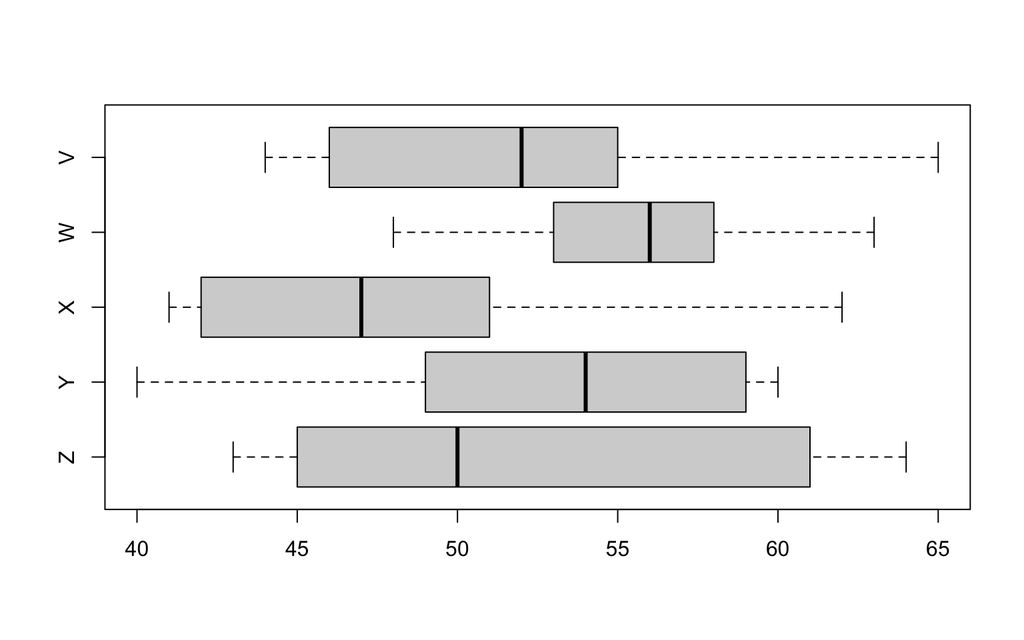

1. Which sample contains the largest value? ##ANSWER1##
2. Which sample contains the smallest value? ##ANSWER2##
3. Which sample has the largest median? ##ANSWER3##
4. Which sample has the smallest median? ##ANSWER4##
5. Which sample has the largest IQR? ##ANSWER5##
6. Which sample has the smallest IQR? ##ANSWER6##

## Answerlist

- V
- W
- X
- Y
- Z
- V
- W
- X
- Y
- Z
- V
- W
- X
- Y
- Z
- V
- W
- X
- Y
- Z
- V
- W
- X
- Y
- Z
- V
- W
- X
- Y
- Z

# Solution

[video](https://vimeo.com/531912457)

1. V. You find the sample with a whisker that goes furthest to the right.
2. Y. You find the sample with a whisker that goes furthest to the left.
3. W. You find the sample with the median (thick line in middle of box) furthest to the right.
4. X. You find the sample with the median (thick line in middle of box) furthest to the left.
5. Z. You find the sample with the widest box.
6. W. You find the sample with the narrowest box.

# Meta-information

extype: cloze exclozetype: schoice|schoice|schoice|schoice|schoice|schoice exsolution: 10000|00010|01000|00100|00001|01000 exname: compare_boxplots